# Plotting with matplotlib

March 31, 2020

We all explore matplotlib together!

# Plotting with matplotlib

## Outline:

1. What is matplotlib?
   - Library of functions to represent data (plots, charts, images, etc.)
   - Making plots is easy, but...
   - Utilizing the full power of mpl requires understanding what's going on under the hood (a little, at least)
1. Pythonic vs. Matlabby
   - How python likes to do things: explicitly reference figure you want to work on (state-independent)
   - How matlab does things: work on *active* figure (state-dependent)
   - matplotlib allows both (with incomplete overlap). We will try to be pythonic.
1. Understanding matplotlib objects
   - plt.subplots() -- not so intuitive way to create a figure
   - The top-level object created by mpl is the *figure*
   - A *figure* object contains one or more *axes* objects (shitty name...these are like subplots or panels)
   - *Axes* objects contain all the things to make a plot: axis, colors, labels, etc.
   - Anatomy of a figure (picture)
1. Let's plot!
   - Make a 2-panel figure using python and matlab styles
   - Complex figures are made using separate calls to create the various parts (data, axes, titles, etc.)
   - Infinite customization: example of gridspec + image display

## Some useful websites:

- [Documentation for axes class](https://matplotlib.org/api/axes_api.html?highlight=axes%20class)
- [List of plot types available in matplotlib](https://matplotlib.org/api/axes_api.html?highlight=axes%20class#plotting)
- [Excellent beginnger/intermediate guide to plotting with matplotlib](https://realpython.com/python-matplotlib-guide/) (basis for this guide)
- [Numpy tutorial](https://docs.scipy.org/doc/numpy/user/quickstart.html), if you're not familiar with it.

## What is matplotlib?

Matplotlib is a bunch of code (Python calls them "modules") that allows us to plot and visualize data using Python. Many of us have used it, and making a basic plot is really easy:

```python
# Import matplotlib's pyplot and numpy
import matplotlib.pyplot as plt
import numpy as np
```

```python
# Use numpy's random number generation to invent some data that will make a nifty plot
rng = np.arange(50)
rnd = np.random.randint(0,10,size=(3, rng.size))
yrs = 1950 + rng
```

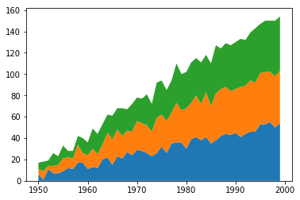

```python
# Look up the syntax on the internet, and plot!
plt.stackplot(yrs, rng + rnd)
fig.tight_layout() # makes a 'cleaner' plot with less whitespace
```

We can then look up a bunch of different plots, ways to add titles, format axis ticks, colors, etc. etc. etc. This works, and it's probably as far as many of us get. But if any of you have dug a little farther, you start running into some confusing stuff. For example, these functions produce some "objects"--what the hell are those? If I make a multi-panel figure, how do I control the different parts? When I google stuff, why does it seem like different people are using totally different syntax to do the same thing (this isn't Perl, dammit!)

If you're going to do anything beyond basic plotting, it's super useful to understand a little bit of "theory" (used loosely here) behind matplotlib. So let's dig in and try to clear up some of the confusion and understand what's going on. Luckily, it's pretty straightforward--you just need a little info.

## Python vs. Matlab: a little history to explain some matplotlib quirks

History is useful here. John D. Hunter (a neurobiologist) started matplotlib in 2003 as an attempt to basically implement the plotting/visualization tools form Matlab (pay software) to Python (open-source). He did a great job, and it has since expanded beyond its Matlab origins. BUT, those origins lead to some of the confusion experienced while using matplotlib. The problem is that Python and Matlab have significantly different styles. To illustrate, let's say you have a two panel figure and are working on two plots, which we'll call plot1 and plot2, and you want to call some function on each of them. Using *PSEUDOCODE*, the "pythonic" way to talk to work on these would be:

```
plot1.somefunction()
plot2.somefunction()
```

The "matlabby" way to do this would be:

```
activate(plot1)
somefunction(plot1)
activate(plot2)
somefunction(plot2)
```

Matlab prefers functions that "belong" to the system, and which plot they work on depends on the state of the system--which plot is active. One plot is active at a time, functions you call work on the active plot, to work on a plot you have to activate it. Simple enough.

In Python, each plot is a distinct object, and you use object syntax to refer to each plot explicitly and call functions that "belong" to the object. Critically, these commands don't reference any "state" of the system--the function simply works on its parent object and doesn't need to know which plot is active.

FYI: The Matlab way of doing things is referred to as "stateful" or "state-based", and the python style is "stateless", "object-oriented", or "OO". Just in case you see those terms around.

#### Which does matplotlib use?

Both! In matplotlib, you can use object-oriented style to work directly on the objects that you generate, or you can use system-level functions. This is great, right? It just means you can pick the style you prefer. Except...the two styles aren't completely overlapping. Most methods can be called both ways, but there are some methods that can only be called one way.

If you're thinking "well that's just super fucking dumb what in the actual hell?" the answer is "yes".

But have no fear! Once you understand that both of these exist, it clears up confusion and it's easy to handle. I think best practice (assuming you aren't an old Matlab user) is to use the pythonic style wherever possible, though managing active figures is super easy and we will learn that too.

### What's in a name? Headaches, that's what

You may have a different experience, but I have found that one of the barriers to using matplotlib is that many of the names are terribly unintuitive. I'll try to explain the names in a way that makes more sense to me and hopefully some sense to you...